# Part I - Analysis of Ford GoBike System Data

## Introduction

> Ford GoBike is a regional public bicycle sharing system in the San Francisco Bay Area, California. This data set includes information about individual rides made in the month of February 2019 using Ford GoBike.

## Preliminary Wrangling

```python
# import all packages and set plots to be embedded inline
import numpy as np
import pandas as pd
import matplotlib.pyplot as plt
import seaborn as sns
import datetime as dt

%matplotlib inline

import warnings
warnings.filterwarnings('ignore')
```

```python
df_main = pd.read_csv('201902-fordgobike-tripdata.csv')
df = df_main.copy()
df.tail()
```

|  | duration_sec | start_time | end_time | start_station_id | start_station_name | start_station_latitude | start_station_longitude | end_station_id | end_station_name | end_station_latitude | end_station_longitude | bike_id | user_type | member_birth_year | member_gender | bike_share_for_all_trip |
| --- | --- | --- | --- | --- | --- | --- | --- | --- | --- | --- | --- | --- | --- | --- | --- | --- |
| 183407 | 480 | 2019-02-01 00:04:49.7240 | 2019-02-01 00:12:50.0340 | 27.0 | Beale St at Harrison St | 37.788059 | -122.391865 | 324.0 | Union Square (Powell St at Post St) | 37.788300 | -122.408531 | 4832 | Subscriber | 1996.0 | Male | No |
| 183408 | 313 | 2019-02-01 00:05:34.7440 | 2019-02-01 00:10:48.5020 | 21.0 | Montgomery St BART Station (Market St at 2nd St) | 37.789625 | -122.400811 | 66.0 | 3rd St at Townsend St | 37.778742 | -122.392741 | 4960 | Subscriber | 1984.0 | Male | No |
| 183409 | 141 | 2019-02-01 00:06:05.5490 | 2019-02-01 00:08:27.2200 | 278.0 | The Alameda at Bush St | 37.331932 | -121.904888 | 277.0 | Morrison Ave at Julian St | 37.333658 | -121.908586 | 3824 | Subscriber | 1990.0 | Male | Yes |
| 183410 | 139 | 2019-02-01 00:05:34.3600 | 2019-02-01 00:07:54.2870 | 220.0 | San Pablo Ave at MLK Jr Way | 37.811351 | -122.273422 | 216.0 | San Pablo Ave at 27th St | 37.817827 | -122.275698 | 5095 | Subscriber | 1988.0 | Male | No |
| 183411 | 271 | 2019-02-01 00:00:20.6360 | 2019-02-01 00:04:52.0580 | 24.0 | Spear St at Folsom St | 37.789677 | -122.390428 | 37.0 | 2nd St at Folsom St | 37.785000 | -122.395936 | 1057 | Subscriber | 1989.0 | Male | No |

```python
df.shape
```

```
(183412, 16)
```

```python
df.info()
```

```
<class 'pandas.core.frame.DataFrame'>
RangeIndex: 183412 entries, 0 to 183411
Data columns (total 16 columns):
 #   Column                   Non-Null Count   Dtype
---  ------                   --------------   -----
 0   duration_sec             183412 non-null  int64
 1   start_time               183412 non-null  object
 2   end_time                 183412 non-null  object
 3   start_station_id         183215 non-null  float64
 4   start_station_name       183215 non-null  object
 5   start_station_latitude   183412 non-null  float64
 6   start_station_longitude  183412 non-null  float64
 7   end_station_id           183215 non-null  float64
 8   end_station_name         183215 non-null  object
 9   end_station_latitude     183412 non-null  float64
 10  end_station_longitude    183412 non-null  float64
 11  bike_id                  183412 non-null  int64
 12  user_type                183412 non-null  object
 13  member_birth_year        175147 non-null  float64
 14  member_gender            175147 non-null  object
 15  bike_share_for_all_trip  183412 non-null  object
dtypes: float64(7), int64(2), object(7)
memory usage: 22.4+ MB
```

```python
df.duplicated().sum()
```

```
0
```

```python
df.isna().sum()
```

```
duration_sec                  0
start_time                    0
end_time                      0
start_station_id            197
start_station_name          197
start_station_latitude        0
start_station_longitude       0
end_station_id              197
end_station_name            197
end_station_latitude          0
end_station_longitude         0
bike_id                       0
user_type                     0
member_birth_year          8265
member_gender              8265
bike_share_for_all_trip       0
dtype: int64
```

```python
# dropping nan values
df.dropna(inplace=True)
```

```python
df.shape
```

```
(174952, 16)
```

```python
# deleting unwanted columns
cols_del = ['end_station_longitude','end_station_latitude',
            'start_station_longitude','start_station_latitude']
df.drop(cols_del, axis=1, inplace=True)
```

```python
df.columns
```

```
Index(['duration_sec', 'start_time', 'end_time', 'start_station_id',
       'start_station_name', 'end_station_id', 'end_station_name', 'bike_id',
       'user_type', 'member_birth_year', 'member_gender',
       'bike_share_for_all_trip'],
      dtype='object')
```

```python
df.user_type.value_counts()
```

```
Subscriber    158386
Customer       16566
Name: user_type, dtype: int64
```

```python
df.member_gender.value_counts()
```

```
Male      130500
Female     40805
Other       3647
Name: member_gender, dtype: int64
```

```python
df.bike_share_for_all_trip.value_counts()
```

```
No     157606
Yes     17346
Name: bike_share_for_all_trip, dtype: int64
```

```python
df.start_station_name.nunique(), df.end_station_name.nunique()
```

```
(329, 329)
```

```python
# changing datatype of time related columns
df['start_time'] = pd.to_datetime(df['start_time'])
df['end_time'] = pd.to_datetime(df['end_time'])

# finding hour, day, month and year
df['start_hour'] = df['start_time'].dt.hour
df['start_day'] = df['start_time'].dt.strftime('%a')
```

```python
# converting days to categorical column
days = ['Mon','Tue','Wed','Thu','Fri', 'Sat', 'Sun']
days_dtype = pd.api.types.CategoricalDtype(categories = days, ordered = True)
df['start_day'] = df['start_day'].astype(days_dtype)
```

```python
# calculating member age
df['member_birth_year'] = df['member_birth_year'].astype(int)
df['member_age'] = 2019 - df['member_birth_year']
```

```python
df['duration_min'] = df['duration_sec']/60
```

```python
df.duration_min.describe()
```

```
count    174952.000000
mean         11.733379
std          27.370082
min           1.016667
25%           5.383333
50%           8.500000
75%          13.150000
max        1409.133333
Name: duration_min, dtype: float64
```

```python
df.info()
```

```
<class 'pandas.core.frame.DataFrame'>
Int64Index: 174952 entries, 0 to 183411
Data columns (total 16 columns):
 #   Column                   Non-Null Count   Dtype
---  ------                   --------------   -----
 0   duration_sec             174952 non-null  int64
 1   start_time               174952 non-null  datetime64[ns]
 2   end_time                 174952 non-null  datetime64[ns]
 3   start_station_id         174952 non-null  float64
 4   start_station_name       174952 non-null  object
 5   end_station_id           174952 non-null  float64
 6   end_station_name         174952 non-null  object
 7   bike_id                  174952 non-null  int64
 8   user_type                174952 non-null  object
 9   member_birth_year        174952 non-null  int64
 10  member_gender            174952 non-null  object
 11  bike_share_for_all_trip  174952 non-null  object
 12  start_hour               174952 non-null  int64
 13  start_day                174952 non-null  category
 14  member_age               174952 non-null  int64
 15  duration_min             174952 non-null  float64
dtypes: category(1), datetime64[ns](2), float64(3), int64(5), object(5)
memory usage: 21.5+ MB
```

### What is the structure of your dataset?

> The dataset is left with 174952 records of rides which have complete information of all variables. There are 16 different variables. Out of which we will be focusing on 10 for our analysis.

### What is/are the main feature(s) of interest in your dataset?

> Main features we are interested to analyze are:
> - Duration of bike trips
> - Number of bike trips

### What features in the dataset do you think will help support your investigation into your feature(s) of interest?

> The main features/factors affecting the number & duration of bike trips are:
> - Age
> - Gender
> - User Type
> - Bike Share Status
> - Time

> These features will support our investigation on Duration of bike trips and Number of trips.

## Univariate Exploration

```python
blue = '#4eb3f2'
purple = '#936cf5'
orange = '#f5916c'
dark_blue = '#2a6ed4'
sns.set_palette('Accent')
plt.rcParams.update({'font.size': 12})
```

**How is Trip Duration distributed?**

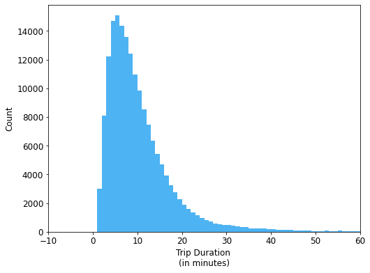

```python
plt.figure(figsize = (8,6))
binsize = 1
bins = np.arange(0, df['duration_min'].max() + binsize, binsize)
plt.hist(data = df, x = 'duration_min', bins = bins, color = blue)
plt.xlim((-10,60))
plt.xlabel('Trip Duration \n(in minutes)')
plt.ylabel('Count')
plt.show()
```

> The distribution of Trip Duration is heavily right-skewed. Duration of most of the trips was in between 0-30 mins. Applying a log scale transformation can convert the shape to a helpful normal curve and reduce the log tail.

```python
# filtering mins smaller than 100
df = df[df['duration_min'] <= 100]
```

```python
np.log10(df.duration_min.describe())
```

```
count    5.241170
mean     1.023836
std      0.927498
min      0.007179
25%      0.729705
50%      0.928567
75%      1.116165
max      1.998985
Name: duration_min, dtype: float64
```

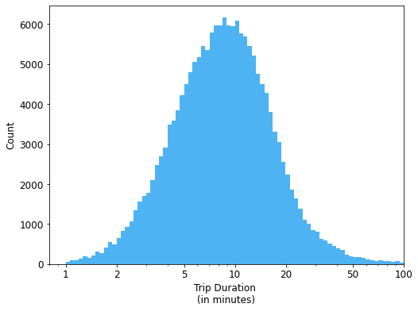

```python
plt.figure(figsize = (8,6))
binsize = 0.025
bins = 10 ** np.arange(0, np.log10(df.duration_min.describe()['max']) + binsize, binsize)
plt.hist(data = df, x = 'duration_min', bins = bins, color = blue)
plt.xscale('log')
plt.xticks([1, 2, 5, 10, 20, 50, 100, 200, 500], [1, 2, 5, 10, 20, 50, 100, 200, 500]);
plt.xlim(0,100)
plt.xlabel('Trip Duration \n(in minutes)')
plt.ylabel('Count')
plt.show()
```

> The distribution appears to be normally distributed now. With most of the trips ranging from 1-50 minutes.

**How is the Member Age distributed?**

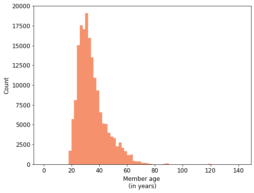

```python
plt.figure(figsize = (8,6))
binsize = 2
bins = np.arange(0, df['member_age'].max() + binsize, binsize)
plt.hist(data = df, x = 'member_age', bins = bins, color = orange)
plt.xlabel('Member age \n(in years)')
plt.ylabel('Count')
plt.show()
```

```python
df.member_age.describe()
```

```
count    174249.000000
mean         34.191972
std          10.117930
min          18.000000
25%          27.000000
50%          32.000000
75%          39.000000
max         141.000000
Name: member_age, dtype: float64
```

```python
df[df['member_age']==141]
```

|  | duration_sec | start_time | end_time | start_station_id | start_station_name | end_station_id | end_station_name | bike_id | user_type | member_birth_year | member_gender | bike_share_for_all_trip | start_hour | start_day | member_age | duration_min |
| --- | --- | --- | --- | --- | --- | --- | --- | --- | --- | --- | --- | --- | --- | --- | --- | --- |
| 27370 | 1474 | 2019-02-25 09:28:42.161 | 2019-02-25 09:53:17.068 | 15.0 | San Francisco Ferry Building (Harry Bridges Pl... | 386.0 | 24th St at Bartlett St | 6436 | Customer | 1878 | Female | No | 9 | Mon | 141 | 24.566667 |

Max age doesn't seem right. The birth year of this user seems to be incorrect (maybe a typing error). The correct year can presumably be 1978.

```python
df.loc[27370,'member_birth_year'] = 1978
df['member_age'] = 2019 - df['member_birth_year']
```

```python
df.member_age.describe()
```

```
count    174249.000000
mean         34.191399
std          10.114707
min          18.000000
25%          27.000000
50%          32.000000
75%          39.000000
max         119.000000
Name: member_age, dtype: float64
```

Let's only consider the data where age < 100. This will help to remove the outliers.

```python
df = df[df.member_age < 100]
```

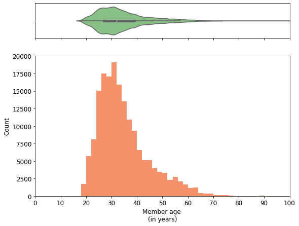

```python
fig, ax = plt.subplots(2, 1, sharex = True, figsize = (9,7), gridspec_kw = dict(height_ratios = [1,4]))
sns.violinplot(data = df, x = df.member_age, ax = ax[0]);
ax[0].set_xlabel(' ');

binsize = 2
bins = np.arange(0, df['member_age'].max() + binsize, binsize)
ax[1].hist(data = df, x = 'member_age', bins = bins, color = orange)
plt.xlim(0,100);
plt.xticks([0,10,20,30,40,50,60,70,80,90,100], [0,10,20,30,40,50,60,70,80,90,100])
plt.xlabel('Member age \n(in years)')
plt.ylabel('Count')
plt.show()
```

> The data seem to be normally distributed with a decent right-skew. Most of the users are 20-60 years of age. Median age is at ~30 years.

**The number of trips as per the Starting Hour of the trip**

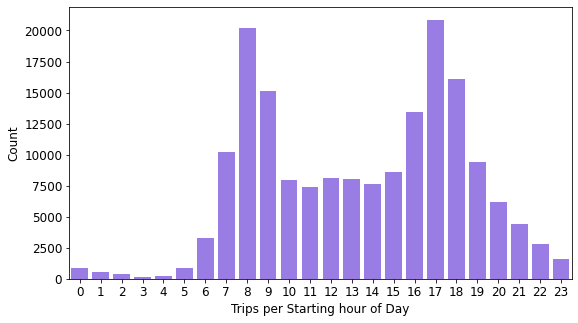

```python
plt.figure(figsize = (9,5))
sns.countplot(data = df, x = 'start_hour', color = purple);
plt.xlabel('Trips per Starting hour of Day');
plt.ylabel('Count');
```

> The distribution is bimodal. With peaks at 8 am and 5 pm. This may be due to the start and end of typical working hours in city of San Francisco.

**The number of trips as per the day of the week**

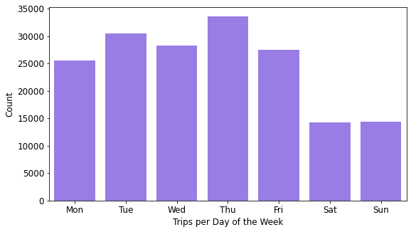

```python
plt.figure(figsize = (9,5))
sns.countplot(data = df, x = 'start_day', color = purple);
plt.xlabel('Trips per Day of the Week');
plt.ylabel('Count');
```

> The data is almost uniform for first 5 days of the week. While on weekends the number of trips is less significantly.

**Gender of all users and User Types.**

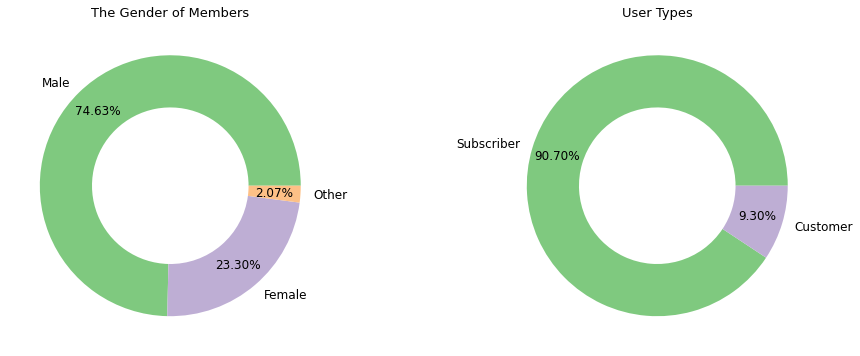

```python
plt.figure(figsize = (16,6));

# Member Gender
plt.subplot(1, 2, 1)
plt.pie(df.member_gender.value_counts(), labels = df.member_gender.value_counts().index,
        autopct = '%2.2f%%', pctdistance = 0.8,
        wedgeprops = dict(width = 0.4));
plt.title('The Gender of Members', fontsize=13);

# User Types
plt.subplot(1, 2, 2)
plt.pie(df.user_type.value_counts(), labels = df.user_type.value_counts().index,
        autopct = '%2.2f%%', pctdistance = 0.8,
        wedgeprops = dict(width = 0.4));
plt.title('User Types', fontsize = 13);
```

> Most of the user base appears to be Male compared to Females. And Subscribers take most of the bike rides than regular customers.

**How many of the Bike Trips were shared?**

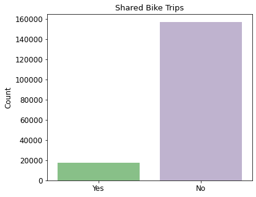

```python
plt.figure(figsize = (6,5));
sns.countplot(data = df, x = 'bike_share_for_all_trip', order = ['Yes','No']);
plt.title('Shared Bike Trips', fontsize = 13);
plt.ylabel('Count');
plt.xlabel('');
```

> A very low number of bike trips done in Feb 2019 were shared. Most of the users ride individually.

### Discuss the distribution(s) of your variable(s) of interest. Were there any unusual points? Did you need to perform any transformations?

> The variable of interest here is `Duration of the trip`. The distribution for duration was heavily skewed to the right. So I applied a 'log' scale transformation on the x-axis. This helped to convert the distribution to normally shapped one.

### Of the features you investigated, were there any unusual distributions? Did you perform any operations on the data to tidy, adjust, or change the form of the data? If so, why did you do this?

> Other features we investigated were:
> - `Member Age`: Most of the users are between 20-60 years of age naturally. The dataset seem to have incorrect inputs about age, which is why maximum age is stretched upto 141 years. I filtered he data to show users with age below 100 years. This helped to reduce the unnecessary long tail of the distribution. Median age is at ~30 years
> - `Starting Hour`: This distribution is bi-modal. With peaks at 8 am and 5 pm. This may be due to the start and end of typical working hours in city of San Francisco
> - `Starting Day of the week`: The data is almost uniform with few ups and dows for first 5 days of the week. While on weekends the number of trips is less significantly.
> - `Member Age`: Most of the user base appears to be Male, about 75% whereas Females comprise of about 23% and 2% others.
> - `User Type`: Subscribers take most of the bike rides (90%) than Regular Customers.
> - `Shared Bike Trips`: A very low number of bike trips done in Feb 2019 were shared. Most of the users ride individually.

## Bivariate Exploration

```python
# dividing features into categorical and numerical
numeric_vars = ['start_hour', 'duration_min', 'member_age', 'member_birth_year']
categoric_vars = ['start_day', 'member_gender', 'user_type', 'bike_share_for_all_trip']
```

To start off, let's check the correlation between **all numeric variables**?

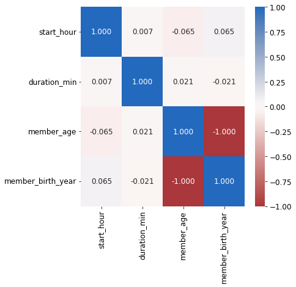

```python
# correlation plot
plt.figure(figsize = [6,6])
sns.heatmap(df[numeric_vars].corr(), annot = True, fmt = '.3f', cmap = 'vlag_r');
```

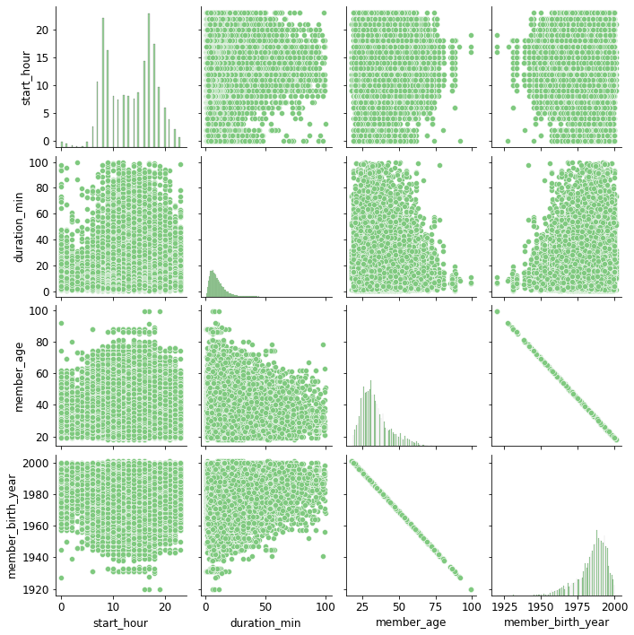

```python
# pair plot matrix between all numeric variables
plt.figure(figsize = [10,10])
sns.pairplot(data = df[numeric_vars])
plt.show()
```

> - As expected, there is a negative correaltion between 'member_age' and 'member_birth_year'. Apart from that there > is no significant corlinearity between other numeric variables.
> - Although, there is no colinearity, we can see a pattern between 'member_age' and 'duration_min'. To some extent, it can be seen that Duration decreases as Age of the user increases.
> - There is also a pattern between 'start_hour' and 'duration_min' which will be explored further.

Comparing 2 numeric variables:

**How is 'Trip Duration' related to 'Member Age'**?

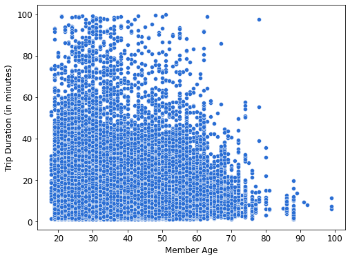

```python
plt.figure(figsize = [8,6])
sns.scatterplot(data = df, x = 'member_age', y = 'duration_min', color = dark_blue);
plt.xlabel('Member Age')
plt.ylabel('Trip Duration (in minutes)');
```

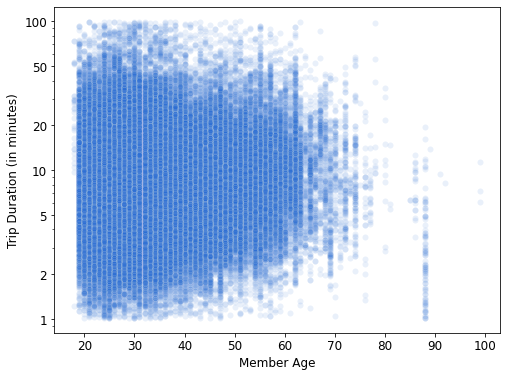

```python
# Applying 'Log' transform to y-axis.
plt.figure(figsize = [8,6])
sns.scatterplot(data = df, x = 'member_age', y = 'duration_min', color = dark_blue, alpha = 1/10);
plt.yscale('log');
plt.yticks([1, 2, 5, 10, 20, 50, 100], [1, 2, 5, 10, 20, 50, 100]);
plt.xlabel('Member Age')
plt.ylabel('Trip Duration (in minutes)');
```

> Still a linear relation cannot be established between Member Age and Duration. But we can see that the data is evenly distributed compared to previous scatter plot.

**How is the 'Trip Duration' related to 'Start Hour of the trip'?**

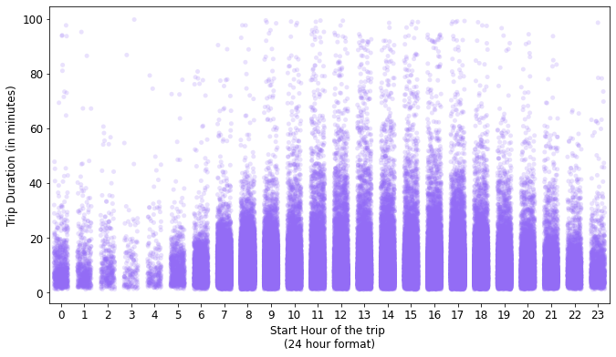

```python
plt.figure(figsize = [11,6])
sns.stripplot(data = df, x = 'start_hour', y = 'duration_min', color = purple, jitter = 0.3, alpha = 1/5);
plt.xlabel('Start Hour of the trip \n(24 hour format)')
plt.xticks(np.arange(0,24), np.arange(0,24));
plt.ylabel('Trip Duration (in minutes)');
```

**How is the 'Member Age' related to 'Start Hour of the trip'?**

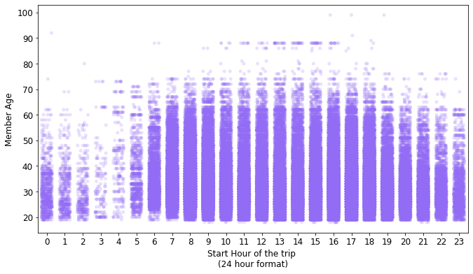

```python
plt.figure(figsize = [11,6])
sns.stripplot(data = df, x = 'start_hour', y = 'member_age', color = purple, jitter = 0.3, alpha = 1/5);
plt.xlabel('Start Hour of the trip \n(24 hour format)')
plt.xticks(np.arange(0,24), np.arange(0,24));
plt.ylabel('Member Age');
```

> Most of the elderly men take rides during day-time. The age of users after 8pm to 6am is significantly lower than mid-day time.

Comparing **Numeric Variables against Categorical variables**

(taking sample to reduce overlapping and make the plots telligible)

```python
# taking a sample of 1000
np.random.seed(99)
samples = np.random.choice(df.shape[0], 1000, replace = False);
df_sample = df.iloc[samples, :];
```

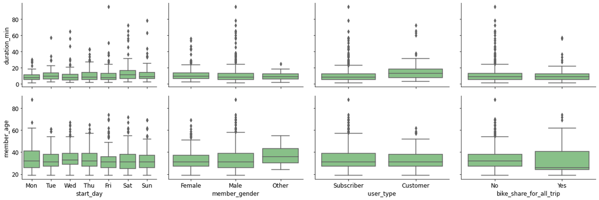

```python
# plot matrix of numeric features against categorical features
def boxgrid(x, y, **kwargs):
    """ Quick hack for creating box plots with seaborn's PairGrid. """
    default_color = sns.color_palette()[0];
    sns.boxplot(x, y, color = default_color);

plt.figure(figsize = [15, 20]);
g = sns.PairGrid(data = df_sample, y_vars = ['duration_min', 'member_age'],
                 x_vars = ['start_day', 'member_gender', 'user_type', 'bike_share_for_all_trip'],
                 height = 3, aspect = 1.5);
g.map(boxgrid);
plt.show()
```

> Certain observations can be made from the abov plot:
> - The duration of the trip is somewhat larger at the later days of the week. And, users of all ages use the bikes across all days uniformly. thought the mean age of users on initial days of the week is slightly higher compared to later days.
> - The age group of Males and Females is almost same. Other gender people are relatively older. All the genders have same trip durations. But only some Males have duration as high as 100mins
> - Customers have significantly high trip durations compared to Subcribers. Whereas the age group of Subcribers is more than the Customers.
> - Youger people take more shared trips. Duration of both shared and unshared trips is almost same.

Plot the **categorical variables** against **duration_min & member_age again**, this time with full data and variable transforms

```python
def log_trans(x, inverse = False):
    """ quick function for computing log and power operations """
    if not inverse: return np.log10(x)
    else: return np.power(10, x)

df['log_duration_min'] = df['duration_min'].apply(log_trans)
```

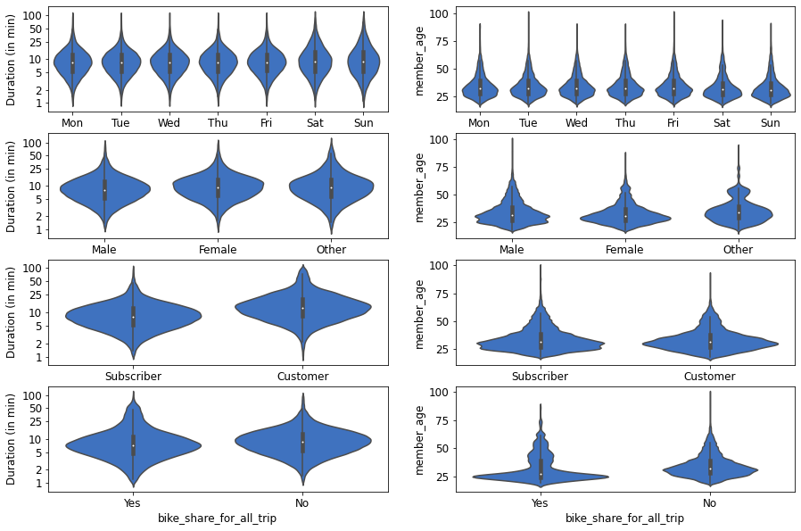

```python
# plot the categorical variables against duration_min and member_age again, this time
# with full data and variable transforms
fig, ax = plt.subplots(ncols = 2, nrows = 4 , figsize = [15,10])

for i in range(len(categoric_vars)):
    var = categoric_vars[i]
    sns.violinplot(data = df, x = var, y = 'log_duration_min', ax = ax[i,0], color = dark_blue);
    ax[i,0].set_yticks(log_trans(np.array([1, 2, 5, 10, 25, 50, 100])));
    ax[i,0].set_yticklabels([1, 2, 5, 10, 25, 50, 100]);
    ax[i,0].set_ylabel('Duration (in min)')
    sns.violinplot(data = df, x = var, y = 'member_age', ax = ax[i,1], color =  dark_blue);
```

> Observations made from above plot matrix which has data from the entire dataset.
> - Log transform has made the shape of violin-graphs more uniform and evenly distributed.
> - Bike rides during later days (weekends) of the weeks have longer durations.
> - Female users ride bikes for slightly longer duration compared to Males. And, other genders also have longer rides compared to Males.
> - Customer do longer rides than Subscribers.
> - Naturally Shared rides are somewhat shorter than non-shared rides.
> - All age members use bikes everyday of the week. Median age is around 30 for all days of the week.
> - Males have a diverse age distribution compared to Females. Other gender age distributuion is bimodal.
> - Slight difference in age distribution for Subcribers and Customers. Subscribers are a bit older than customers.
> - People who are youger take shared rides more.

Now, let's look at relationships between all the **categorical features.**

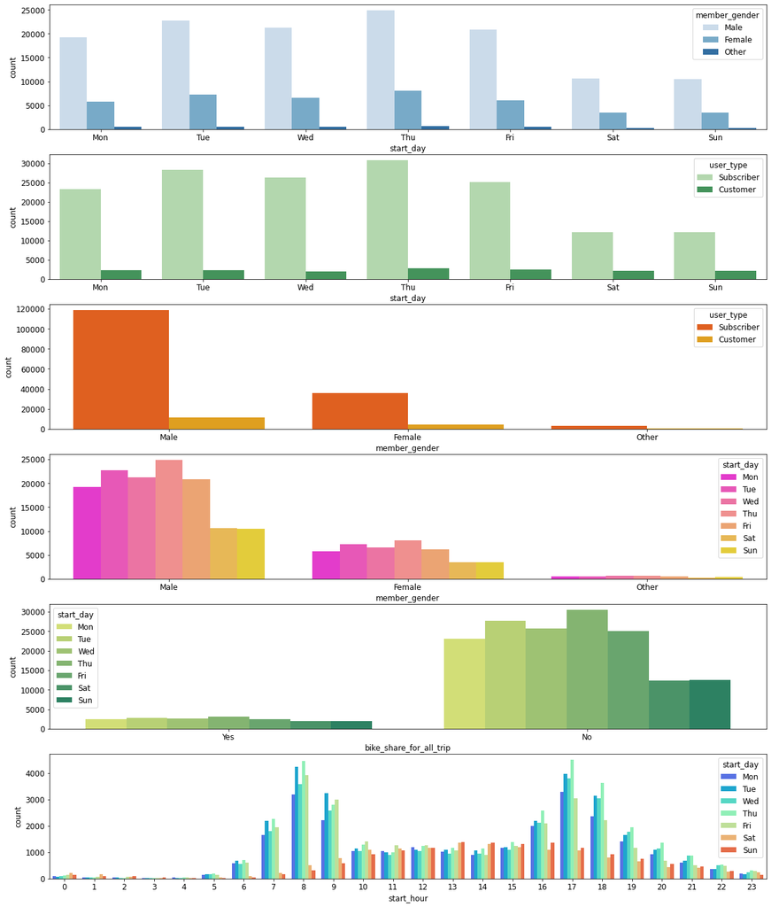

```python
plt.figure(figsize = [20,25]);

ax = plt.subplot(6, 1, 1);
sns.countplot(data = df, x = 'start_day', hue = 'member_gender', palette = 'Blues');

ax = plt.subplot(6, 1, 2);
sns.countplot(data = df, x = 'start_day', hue = 'user_type', palette = 'Greens');

ax = plt.subplot(6, 1, 3);
sns.countplot(data = df, x = 'member_gender', hue = 'user_type', palette = 'autumn');

ax = plt.subplot(6, 1, 4);
sns.countplot(data = df, x = 'member_gender', hue = 'start_day', palette = 'spring');

ax = plt.subplot(6, 1, 5);
sns.countplot(data = df, x = 'bike_share_for_all_trip', hue = 'start_day', palette = 'summer_r');

ax = plt.subplot(6, 1, 6);
sns.countplot(data = df, x = 'start_hour', hue = 'start_day', palette = 'rainbow');
```

## Multivariate Exploration

**Comparing the No. of trips per hour of the day for each Gender and each User Type**

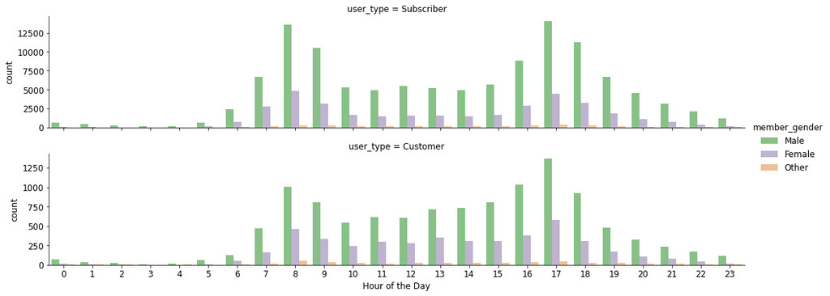

```python
sns.catplot(data = df, x = 'start_hour', row = 'user_type',  hue = 'member_gender',
            height = 3, aspect = 5, sharey = False, kind = 'count');
plt.xlabel('Hour of the Day');
```

**Comparing the No. of trips per hour of the day for each day of the week and each User Type**

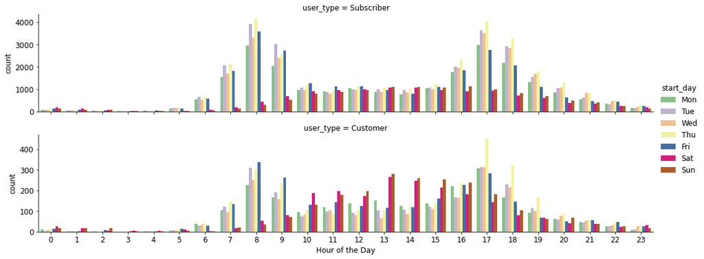

```python
sns.catplot(data = df, x = 'start_hour', row = 'user_type',  hue = 'start_day',
            height = 3, aspect = 5, sharey = False, kind = 'count');
plt.xlabel('Hour of the Day');
```

> - Subscribers take more trips on peak hours during week days. They take relatively less trips on weekends comapred to peak hours of week-days.
> - Customers tend to take more trips on weekends and peak during mid day hours.

**Comparing the No. of trips per day of the week for each Gender and each User Type**

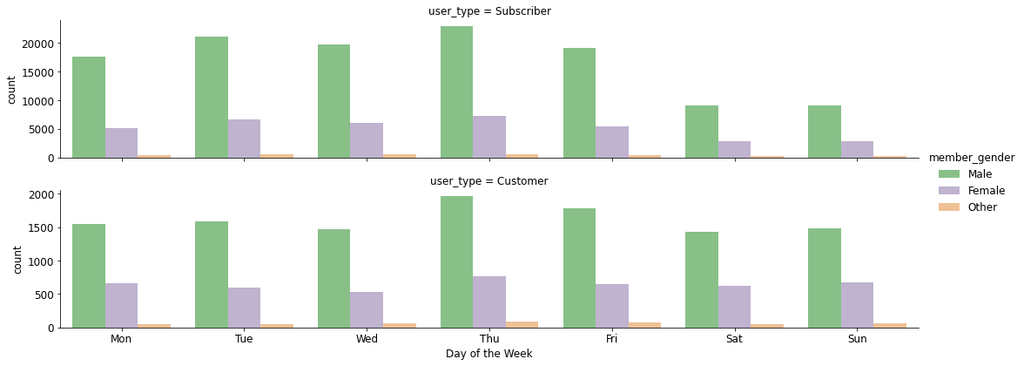

```python
sns.catplot(data = df, x = 'start_day', row = 'user_type',  hue = 'member_gender',
            height = 3, aspect = 5, sharey = False, kind = 'count');
plt.xlabel('Day of the Week');
```

> - Subscribers use the system heavily on work days i.e. Monday through Friday whereas customers ride a lot on weekends
> - Male Subscribers take trips mostly on week-days, Male customers take trips on all days.
> - Female subsribers also take trips on all days (relatively less on weekends).

Defining a function to create hist2d plot with `duration_min` as y-variable and `member_age` as x-variable

```python
def hist2dgrid_1(x, y, **kwargs):
    """ Quick hack for creating heat maps with seaborn's PairGrid. """
    palette = kwargs.pop('color');
    bins_x = np.arange(df['member_age'].min(), df['member_age'].max()+2, 2);
    bins_y = np.arange(0, 2, 0.1);
    plt.hist2d(x, y, bins = [bins_x, bins_y], cmap = palette, cmin = 0.5);
    plt.yticks(log_trans(np.array([1, 2, 5, 10, 20, 50, 100])),
              [1, 2, 5, 10, 20, 50, 100]);
```

Defining a function to create hist2d plot with `duration_min` as y-variable and `start_hour` as x-variable

```python
def hist2dgrid_2(x, y, **kwargs):
    """ Quick hack for creating heat maps with seaborn's PairGrid. """
    palette = kwargs.pop('color');
    bins_x = np.arange(df['start_hour'].min(), df['start_hour'].max()+1, 1);
    bins_y = np.arange(0, 2, 0.1);
    plt.hist2d(x, y, bins = [bins_x, bins_y], cmap = palette, cmin = 0.5);
    plt.yticks(log_trans(np.array([1, 2, 5, 10, 20, 50, 100])),
              [1, 2, 5, 10, 20, 50, 100]);
```

**How does Duration vary with Trip Start Hour for each Day of the week?**

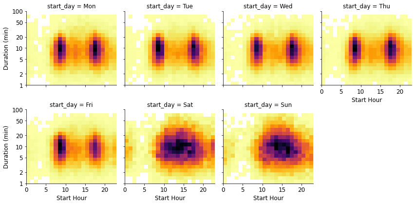

```python
# create faceted heat maps
g = sns.FacetGrid(data = df, col = 'start_day', col_wrap = 4, height = 3);
g.map(hist2dgrid_2, 'start_hour', 'log_duration_min', color = 'inferno_r');
g.set_xlabels('Start Hour');
g.set_ylabels('Duration (min)');
```

> - Duration of the rides is longer on weekends overall.
> - For weekdays the duration is longer and more number of rides take place during the 8-10 and 15-20 hours intervals. For weekends rides are evenly distributed between 8-20 hour interval in general.

**How does Duration vary with Member Age for each Gender?**

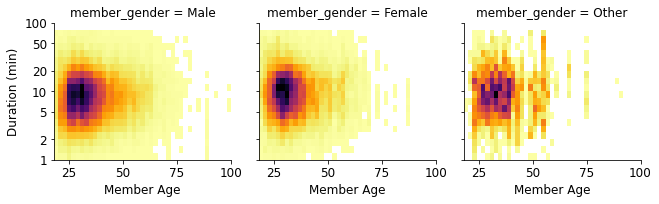

```python
# create faceted heat maps
g = sns.FacetGrid(data = df, col = 'member_gender', col_wrap = 4, height = 3);
g.map(hist2dgrid_1, 'member_age', 'log_duration_min', color = 'inferno_r');
g.set_xlabels('Member Age');
g.set_ylabels('Duration (min)');
```

> - Younger Females take longer rides than younger Males.
> - Whereas more older Males take longer rides than older Females.
> - The distribution for Other gender is intelligible.

**How does Duration vary with Member Age for each User Type?**

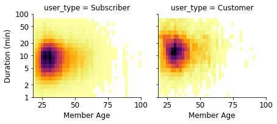

```python
# create faceted heat maps
g = sns.FacetGrid(data = df, col = 'user_type', col_wrap = 4, height = 3);
g.map(hist2dgrid_1, 'member_age', 'log_duration_min', color = 'inferno_r');
g.set_xlabels('Member Age');
g.set_ylabels('Duration (min)');
```

> - Customers take long duration rides than Subscribers of relatively same age.
> - Customers are generally younger than subscribers. Subscribers vary from 18-60yrs, whereas customers vary from 18-45yrs

**How does Duration vary with Member Age wrt each day of the week and each gender?**

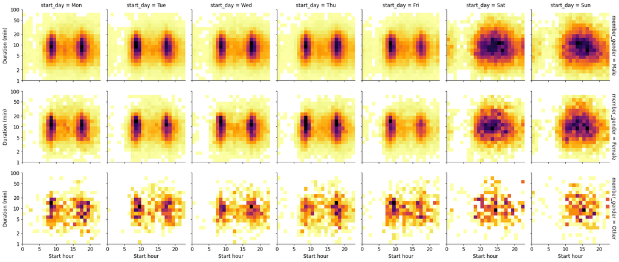

```python
# create faceted heat maps
g = sns.FacetGrid(data = df, row = 'member_gender', col = 'start_day',  height = 3, margin_titles = True);
g.map(hist2dgrid_2, 'start_hour', 'log_duration_min', color = 'inferno_r');
g.set_xlabels('Start hour');
g.set_ylabels('Duration (min)');
```

> - For all the 3 genders the distribution is bimodal for weekdays.
> - Males take longer rides on Saturdays, whereas Females take longer rides on Sundays.

Let's devide bikers into 2 groups by age:

- bikers below 40 years old
- bikers above 40 years old.

```python
young = df.loc[(df['member_age'] < 40),:]
old = df.loc[(df['member_age'] >= 40),:]
```

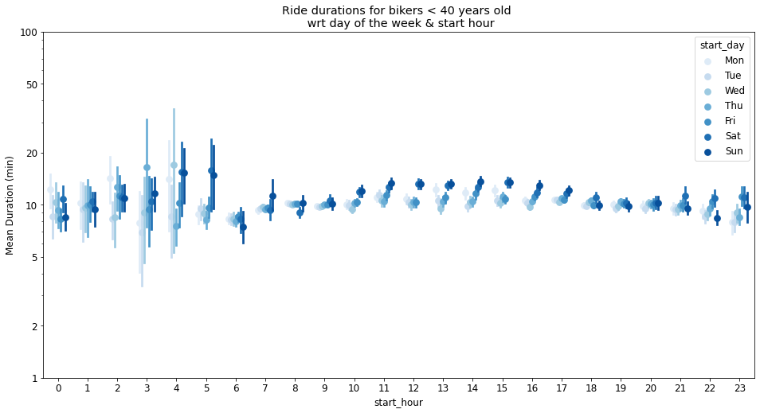

```python
fig = plt.figure(figsize = [16,8])

ax = sns.pointplot(data = young, x = 'start_hour', y = 'duration_min', hue = 'start_day',
           palette = 'Blues', linestyles = '', dodge = 0.5);

plt.title('Ride durations for bikers < 40 years old \n wrt day of the week & start hour');
plt.ylabel('Mean Duration (min)');
plt.yscale('log');
plt.yticks([1, 2, 5, 10, 20, 50, 100], [1, 2, 5, 10, 20, 50, 100]);
ax.set_yticklabels([],minor = True);
```

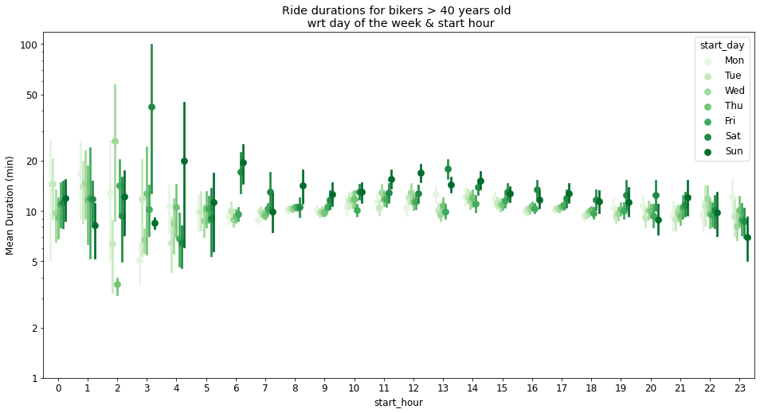

```python
fig = plt.figure(figsize = [16,8])

ax = sns.pointplot(data = old, x = 'start_hour', y = 'duration_min', hue = 'start_day',
           palette = 'Greens', linestyles = '', dodge = 0.5);

plt.title('Ride durations for bikers > 40 years old \n wrt day of the week & start hour');
plt.ylabel('Mean Duration (min)');
plt.yscale('log');
plt.yticks([1, 2, 5, 10, 20, 50, 100], [1, 2, 5, 10, 20, 50, 100]);
ax.set_yticklabels([],minor = True);
```

> - From the errorbars in both pointplots, we can tell that there are less bikers who are older than 40 years old.
> - Users older than 40 years take rides with a more varying trip duration. Whereas users younger than 40 take trips within a short duration range.
> - During early hours od the day, after midnight, the trip duration varies from 5-100 mins for people >40. And i t varies from 3-30 for people <40.
> - The difference in duration for weekends and weekdays is more for older than 40 users than youger than 40 users.

### Talk about some of the relationships you observed in this part of the investigation. Were there features that strengthened each other in terms of looking at your feature(s) of interest?

> We were able to focus on the patterns and relationships discovered in bivariate analysis with more depth wrt other variables. Moslty the features we investigated here are pretty much indenpendant from each other, and their relation doesn't have much significance. Even then, the relation between start hour and trip duration for each day of the week was pretty significant.

## Conclusions

Some of the main conclusions derived from the analysis were:

```python
# Storing clean data-set

df.to_csv('clean_data.csv', index=False)
```